# Risk Factor Analysis

## Outcome Variable

**Outcome Variable:** ever_swasted

## Predictor Variables

**Intervention Variable:** birthwt

**Adjustment Set:**

- arm
- sex
- W_mage
- meducyrs
- feducyrs
- vagbrth
- single
- brthmon
- W_parity
- delta_W_mage
- delta_meducyrs
- delta_feducyrs
- delta_vagbrth
- delta_single
- delta_brthmon
- delta_W_parity

## Stratifying Variables

The analysis was stratified on these variable(s):

- agecat
- studyid
- country

## Data Summary

| agecat | studyid | country | birthwt | ever_swasted | n_cell | n |
| --- | --- | --- | --- | --- | --- | --- |
| 0-24 months (no birth wast) | ki0047075b-MAL-ED | BANGLADESH | Normal or high birthweight | 0 | 195 | 257 |
| 0-24 months (no birth wast) | ki0047075b-MAL-ED | BANGLADESH | Normal or high birthweight | 1 | 9 | 257 |
| 0-24 months (no birth wast) | ki0047075b-MAL-ED | BANGLADESH | Low birth weight | 0 | 50 | 257 |
| 0-24 months (no birth wast) | ki0047075b-MAL-ED | BANGLADESH | Low birth weight | 1 | 3 | 257 |
| 0-24 months (no birth wast) | ki0047075b-MAL-ED | BRAZIL | Normal or high birthweight | 0 | 217 | 232 |
| 0-24 months (no birth wast) | ki0047075b-MAL-ED | BRAZIL | Normal or high birthweight | 1 | 3 | 232 |
| 0-24 months (no birth wast) | ki0047075b-MAL-ED | BRAZIL | Low birth weight | 0 | 12 | 232 |
| 0-24 months (no birth wast) | ki0047075b-MAL-ED | BRAZIL | Low birth weight | 1 | 0 | 232 |
| 0-24 months (no birth wast) | ki0047075b-MAL-ED | INDIA | Normal or high birthweight | 0 | 193 | 238 |
| 0-24 months (no birth wast) | ki0047075b-MAL-ED | INDIA | Normal or high birthweight | 1 | 9 | 238 |
| 0-24 months (no birth wast) | ki0047075b-MAL-ED | INDIA | Low birth weight | 0 | 36 | 238 |
| 0-24 months (no birth wast) | ki0047075b-MAL-ED | INDIA | Low birth weight | 1 | 0 | 238 |
| 0-24 months (no birth wast) | ki0047075b-MAL-ED | NEPAL | Normal or high birthweight | 0 | 210 | 232 |
| 0-24 months (no birth wast) | ki0047075b-MAL-ED | NEPAL | Normal or high birthweight | 1 | 1 | 232 |
| 0-24 months (no birth wast) | ki0047075b-MAL-ED | NEPAL | Low birth weight | 0 | 21 | 232 |
| 0-24 months (no birth wast) | ki0047075b-MAL-ED | NEPAL | Low birth weight | 1 | 0 | 232 |
| 0-24 months (no birth wast) | ki0047075b-MAL-ED | PERU | Normal or high birthweight | 0 | 278 | 299 |
| 0-24 months (no birth wast) | ki0047075b-MAL-ED | PERU | Normal or high birthweight | 1 | 3 | 299 |
| 0-24 months (no birth wast) | ki0047075b-MAL-ED | PERU | Low birth weight | 0 | 18 | 299 |
| 0-24 months (no birth wast) | ki0047075b-MAL-ED | PERU | Low birth weight | 1 | 0 | 299 |
| 0-24 months (no birth wast) | ki0047075b-MAL-ED | SOUTH AFRICA | Normal or high birthweight | 0 | 277 | 308 |
| 0-24 months (no birth wast) | ki0047075b-MAL-ED | SOUTH AFRICA | Normal or high birthweight | 1 | 10 | 308 |
| 0-24 months (no birth wast) | ki0047075b-MAL-ED | SOUTH AFRICA | Low birth weight | 0 | 20 | 308 |
| 0-24 months (no birth wast) | ki0047075b-MAL-ED | SOUTH AFRICA | Low birth weight | 1 | 1 | 308 |
| 0-24 months (no birth wast) | ki0047075b-MAL-ED | TANZANIA, UNITED REPUBLIC OF | Normal or high birthweight | 0 | 126 | 135 |
| 0-24 months (no birth wast) | ki0047075b-MAL-ED | TANZANIA, UNITED REPUBLIC OF | Normal or high birthweight | 1 | 2 | 135 |
| 0-24 months (no birth wast) | ki0047075b-MAL-ED | TANZANIA, UNITED REPUBLIC OF | Low birth weight | 0 | 7 | 135 |
| 0-24 months (no birth wast) | ki0047075b-MAL-ED | TANZANIA, UNITED REPUBLIC OF | Low birth weight | 1 | 0 | 135 |
| 0-24 months (no birth wast) | ki1000108-CMC-V-BCS-2002 | INDIA | Normal or high birthweight | 0 | 278 | 368 |
| 0-24 months (no birth wast) | ki1000108-CMC-V-BCS-2002 | INDIA | Normal or high birthweight | 1 | 50 | 368 |

[output cut: 202 more lines]

The following strata were considered:

- agecat: 0-24 months (no birth wast), studyid: ki0047075b-MAL-ED, country: BANGLADESH
- agecat: 0-24 months (no birth wast), studyid: ki0047075b-MAL-ED, country: BRAZIL
- agecat: 0-24 months (no birth wast), studyid: ki0047075b-MAL-ED, country: INDIA
- agecat: 0-24 months (no birth wast), studyid: ki0047075b-MAL-ED, country: NEPAL
- agecat: 0-24 months (no birth wast), studyid: ki0047075b-MAL-ED, country: PERU
- agecat: 0-24 months (no birth wast), studyid: ki0047075b-MAL-ED, country: SOUTH AFRICA
- agecat: 0-24 months (no birth wast), studyid: ki0047075b-MAL-ED, country: TANZANIA, UNITED REPUBLIC OF
- agecat: 0-24 months (no birth wast), studyid: ki1000108-CMC-V-BCS-2002, country: INDIA
- agecat: 0-24 months (no birth wast), studyid: ki1000108-IRC, country: INDIA
- agecat: 0-24 months (no birth wast), studyid: ki1000109-EE, country: PAKISTAN
- agecat: 0-24 months (no birth wast), studyid: ki1000109-ResPak, country: PAKISTAN
- agecat: 0-24 months (no birth wast), studyid: ki1000304b-SAS-CompFeed, country: INDIA
- agecat: 0-24 months (no birth wast), studyid: ki1017093-NIH-Birth, country: BANGLADESH
- agecat: 0-24 months (no birth wast), studyid: ki1017093b-PROVIDE, country: BANGLADESH
- agecat: 0-24 months (no birth wast), studyid: ki1017093c-NIH-Crypto, country: BANGLADESH
- agecat: 0-24 months (no birth wast), studyid: ki1066203-TanzaniaChild2, country: TANZANIA, UNITED REPUBLIC OF
- agecat: 0-24 months (no birth wast), studyid: ki1101329-Keneba, country: GAMBIA
- agecat: 0-24 months (no birth wast), studyid: ki1114097-CMIN, country: BANGLADESH
- agecat: 0-24 months (no birth wast), studyid: ki1114097-CMIN, country: BRAZIL
- agecat: 0-24 months (no birth wast), studyid: ki1114097-CMIN, country: GUINEA-BISSAU
- agecat: 0-24 months (no birth wast), studyid: ki1114097-CMIN, country: PERU
- agecat: 0-24 months (no birth wast), studyid: ki1114097-CONTENT, country: PERU
- agecat: 0-24 months (no birth wast), studyid: ki1119695-PROBIT, country: BELARUS
- agecat: 0-24 months (no birth wast), studyid: ki1126311-ZVITAMBO, country: ZIMBABWE
- agecat: 0-24 months (no birth wast), studyid: ki1135781-COHORTS, country: GUATEMALA
- agecat: 0-24 months (no birth wast), studyid: ki1135781-COHORTS, country: INDIA
- agecat: 0-24 months (no birth wast), studyid: ki1135781-COHORTS, country: PHILIPPINES
- agecat: 0-24 months (no birth wast), studyid: kiGH5241-JiVitA-3, country: BANGLADESH
- agecat: 0-24 months (no birth wast), studyid: kiGH5241-JiVitA-4, country: BANGLADESH
- agecat: 6-24 months, studyid: ki0047075b-MAL-ED, country: BANGLADESH
- agecat: 6-24 months, studyid: ki0047075b-MAL-ED, country: BRAZIL
- agecat: 6-24 months, studyid: ki0047075b-MAL-ED, country: INDIA
- agecat: 6-24 months, studyid: ki0047075b-MAL-ED, country: NEPAL
- agecat: 6-24 months, studyid: ki0047075b-MAL-ED, country: PERU
- agecat: 6-24 months, studyid: ki0047075b-MAL-ED, country: SOUTH AFRICA
- agecat: 6-24 months, studyid: ki0047075b-MAL-ED, country: TANZANIA, UNITED REPUBLIC OF
- agecat: 6-24 months, studyid: ki1000108-CMC-V-BCS-2002, country: INDIA
- agecat: 6-24 months, studyid: ki1000108-IRC, country: INDIA
- agecat: 6-24 months, studyid: ki1000109-EE, country: PAKISTAN
- agecat: 6-24 months, studyid: ki1000109-ResPak, country: PAKISTAN
- agecat: 6-24 months, studyid: ki1000304b-SAS-CompFeed, country: INDIA
- agecat: 6-24 months, studyid: ki1017093-NIH-Birth, country: BANGLADESH
- agecat: 6-24 months, studyid: ki1017093b-PROVIDE, country: BANGLADESH
- agecat: 6-24 months, studyid: ki1017093c-NIH-Crypto, country: BANGLADESH
- agecat: 6-24 months, studyid: ki1066203-TanzaniaChild2, country: TANZANIA, UNITED REPUBLIC OF
- agecat: 6-24 months, studyid: ki1101329-Keneba, country: GAMBIA
- agecat: 6-24 months, studyid: ki1114097-CMIN, country: BANGLADESH
- agecat: 6-24 months, studyid: ki1114097-CMIN, country: BRAZIL
- agecat: 6-24 months, studyid: ki1114097-CMIN, country: GUINEA-BISSAU
- agecat: 6-24 months, studyid: ki1114097-CMIN, country: PERU
- agecat: 6-24 months, studyid: ki1114097-CONTENT, country: PERU
- agecat: 6-24 months, studyid: ki1119695-PROBIT, country: BELARUS
- agecat: 6-24 months, studyid: ki1126311-ZVITAMBO, country: ZIMBABWE
- agecat: 6-24 months, studyid: ki1135781-COHORTS, country: GUATEMALA
- agecat: 6-24 months, studyid: ki1135781-COHORTS, country: INDIA
- agecat: 6-24 months, studyid: ki1135781-COHORTS, country: PHILIPPINES
- agecat: 6-24 months, studyid: kiGH5241-JiVitA-3, country: BANGLADESH
- agecat: 6-24 months, studyid: kiGH5241-JiVitA-4, country: BANGLADESH

### Dropped Strata

Some strata were dropped due to rare outcomes:

- agecat: 0-24 months (no birth wast), studyid: ki0047075b-MAL-ED, country: BANGLADESH
- agecat: 0-24 months (no birth wast), studyid: ki0047075b-MAL-ED, country: BRAZIL
- agecat: 0-24 months (no birth wast), studyid: ki0047075b-MAL-ED, country: INDIA
- agecat: 0-24 months (no birth wast), studyid: ki0047075b-MAL-ED, country: NEPAL
- agecat: 0-24 months (no birth wast), studyid: ki0047075b-MAL-ED, country: PERU
- agecat: 0-24 months (no birth wast), studyid: ki0047075b-MAL-ED, country: SOUTH AFRICA
- agecat: 0-24 months (no birth wast), studyid: ki0047075b-MAL-ED, country: TANZANIA, UNITED REPUBLIC OF
- agecat: 0-24 months (no birth wast), studyid: ki1000109-ResPak, country: PAKISTAN
- agecat: 0-24 months (no birth wast), studyid: ki1114097-CMIN, country: BANGLADESH
- agecat: 0-24 months (no birth wast), studyid: ki1114097-CMIN, country: BRAZIL
- agecat: 0-24 months (no birth wast), studyid: ki1114097-CMIN, country: GUINEA-BISSAU
- agecat: 0-24 months (no birth wast), studyid: ki1114097-CMIN, country: PERU
- agecat: 0-24 months (no birth wast), studyid: ki1114097-CONTENT, country: PERU
- agecat: 0-24 months (no birth wast), studyid: ki1119695-PROBIT, country: BELARUS
- agecat: 6-24 months, studyid: ki0047075b-MAL-ED, country: BANGLADESH
- agecat: 6-24 months, studyid: ki0047075b-MAL-ED, country: BRAZIL
- agecat: 6-24 months, studyid: ki0047075b-MAL-ED, country: INDIA
- agecat: 6-24 months, studyid: ki0047075b-MAL-ED, country: NEPAL
- agecat: 6-24 months, studyid: ki0047075b-MAL-ED, country: PERU
- agecat: 6-24 months, studyid: ki0047075b-MAL-ED, country: SOUTH AFRICA
- agecat: 6-24 months, studyid: ki0047075b-MAL-ED, country: TANZANIA, UNITED REPUBLIC OF
- agecat: 6-24 months, studyid: ki1000109-ResPak, country: PAKISTAN
- agecat: 6-24 months, studyid: ki1114097-CMIN, country: BANGLADESH
- agecat: 6-24 months, studyid: ki1114097-CMIN, country: BRAZIL
- agecat: 6-24 months, studyid: ki1114097-CMIN, country: GUINEA-BISSAU
- agecat: 6-24 months, studyid: ki1114097-CMIN, country: PERU
- agecat: 6-24 months, studyid: ki1114097-CONTENT, country: PERU
- agecat: 6-24 months, studyid: ki1119695-PROBIT, country: BELARUS

## Methods Detail

We’re interested in the causal parameters $E[Y_a]$ for all values of $a \in \mathcal{A}$. These parameters represent the mean outcome if, possibly contrary to fact, we intervened to set all units to have $A=a$. Under the randomization and positivity assumptions, these are identified by the statistical parameters $\psi_a=E_W[E_{Y|A,W}(Y|A=a,W)]$. In addition, we’re interested in the mean of $Y$, $E[Y]$ under no intervention (the observed mean). We will estimate these parameters by using SuperLearner to fit the relevant likelihood factors – $E_{Y|A,W}(Y|A=a,W)$ and $p(A=a|W)$, and then updating our likelihood fit using a joint TMLE.

For unadjusted analyses ($W=\{\}$), initial likelihoods were estimated using Lrnr_glm to estimate the simple $E(Y|A)$ and Lrnr_mean to estimate $p(A)$. For adjusted analyses, a small library containing Lrnr_glmnet, Lrnr_xgboost, and Lrnr_mean was used.

Having estimated these parameters, we will then use the delta method to estimate relative risks and attributable risks relative to a prespecified baseline level of $A$.

# Results Detail

## Results Plots

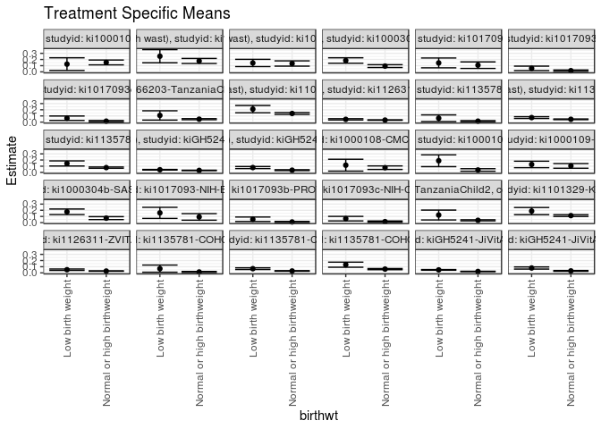

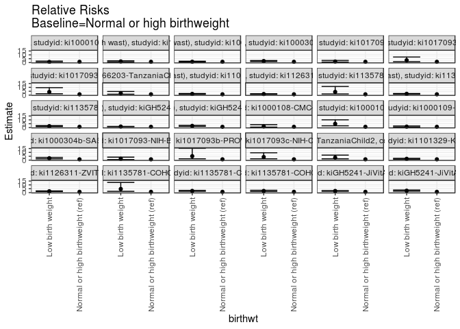

[figure not shown]

[figure not shown]

## Results Table

### Parameter: TSM

| agecat | studyid | country | intervention_level | baseline_level | estimate | ci_lower | ci_upper |
| --- | --- | --- | --- | --- | --- | --- | --- |
| 0-24 months (no birth wast) | ki1000108-CMC-V-BCS-2002 | INDIA | Normal or high birthweight | NA | 0.1524390 | 0.1134865 | 0.1913915 |
| 0-24 months (no birth wast) | ki1000108-CMC-V-BCS-2002 | INDIA | Low birth weight | NA | 0.1250000 | 0.0223715 | 0.2276285 |
| 0-24 months (no birth wast) | ki1000108-IRC | INDIA | Normal or high birthweight | NA | 0.1763128 | 0.1356149 | 0.2170106 |
| 0-24 months (no birth wast) | ki1000108-IRC | INDIA | Low birth weight | NA | 0.2531697 | 0.1464719 | 0.3598674 |
| 0-24 months (no birth wast) | ki1000109-EE | PAKISTAN | Normal or high birthweight | NA | 0.1352142 | 0.0924548 | 0.1779737 |
| 0-24 months (no birth wast) | ki1000109-EE | PAKISTAN | Low birth weight | NA | 0.1438819 | 0.0852520 | 0.2025117 |
| 0-24 months (no birth wast) | ki1000304b-SAS-CompFeed | INDIA | Normal or high birthweight | NA | 0.0933467 | 0.0703683 | 0.1163252 |
| 0-24 months (no birth wast) | ki1000304b-SAS-CompFeed | INDIA | Low birth weight | NA | 0.1836656 | 0.1394396 | 0.2278917 |
| 0-24 months (no birth wast) | ki1017093-NIH-Birth | BANGLADESH | Normal or high birthweight | NA | 0.1082559 | 0.0554517 | 0.1610601 |
| 0-24 months (no birth wast) | ki1017093-NIH-Birth | BANGLADESH | Low birth weight | NA | 0.1444821 | 0.0649413 | 0.2240228 |
| 0-24 months (no birth wast) | ki1017093b-PROVIDE | BANGLADESH | Normal or high birthweight | NA | 0.0189394 | 0.0073041 | 0.0305747 |
| 0-24 months (no birth wast) | ki1017093b-PROVIDE | BANGLADESH | Low birth weight | NA | 0.0566038 | 0.0206590 | 0.0925485 |
| 0-24 months (no birth wast) | ki1017093c-NIH-Crypto | BANGLADESH | Normal or high birthweight | NA | 0.0155440 | 0.0054613 | 0.0256267 |
| 0-24 months (no birth wast) | ki1017093c-NIH-Crypto | BANGLADESH | Low birth weight | NA | 0.0628571 | 0.0268741 | 0.0988402 |
| 0-24 months (no birth wast) | ki1066203-TanzaniaChild2 | TANZANIA, UNITED REPUBLIC OF | Normal or high birthweight | NA | 0.0473927 | 0.0386661 | 0.0561193 |
| 0-24 months (no birth wast) | ki1066203-TanzaniaChild2 | TANZANIA, UNITED REPUBLIC OF | Low birth weight | NA | 0.1081140 | 0.0328105 | 0.1834174 |
| 0-24 months (no birth wast) | ki1101329-Keneba | GAMBIA | Normal or high birthweight | NA | 0.1400172 | 0.1244214 | 0.1556130 |
| 0-24 months (no birth wast) | ki1101329-Keneba | GAMBIA | Low birth weight | NA | 0.2107076 | 0.1516691 | 0.2697460 |
| 0-24 months (no birth wast) | ki1126311-ZVITAMBO | ZIMBABWE | Normal or high birthweight | NA | 0.0329543 | 0.0297418 | 0.0361667 |
| 0-24 months (no birth wast) | ki1126311-ZVITAMBO | ZIMBABWE | Low birth weight | NA | 0.0447975 | 0.0347039 | 0.0548912 |
| 0-24 months (no birth wast) | ki1135781-COHORTS | GUATEMALA | Normal or high birthweight | NA | 0.0155131 | 0.0071413 | 0.0238849 |
| 0-24 months (no birth wast) | ki1135781-COHORTS | GUATEMALA | Low birth weight | NA | 0.0632911 | 0.0095700 | 0.1170123 |
| 0-24 months (no birth wast) | ki1135781-COHORTS | INDIA | Normal or high birthweight | NA | 0.0454550 | 0.0398502 | 0.0510598 |
| 0-24 months (no birth wast) | ki1135781-COHORTS | INDIA | Low birth weight | NA | 0.0732205 | 0.0585887 | 0.0878522 |
| 0-24 months (no birth wast) | ki1135781-COHORTS | PHILIPPINES | Normal or high birthweight | NA | 0.0772890 | 0.0672105 | 0.0873676 |
| 0-24 months (no birth wast) | ki1135781-COHORTS | PHILIPPINES | Low birth weight | NA | 0.1444601 | 0.1032606 | 0.1856596 |
| 0-24 months (no birth wast) | kiGH5241-JiVitA-3 | BANGLADESH | Normal or high birthweight | NA | 0.0317001 | 0.0286257 | 0.0347744 |
| 0-24 months (no birth wast) | kiGH5241-JiVitA-3 | BANGLADESH | Low birth weight | NA | 0.0425770 | 0.0381141 | 0.0470398 |
| 0-24 months (no birth wast) | kiGH5241-JiVitA-4 | BANGLADESH | Normal or high birthweight | NA | 0.0354582 | 0.0285804 | 0.0423361 |
| 0-24 months (no birth wast) | kiGH5241-JiVitA-4 | BANGLADESH | Low birth weight | NA | 0.0778455 | 0.0609622 | 0.0947288 |
| 6-24 months | ki1000108-CMC-V-BCS-2002 | INDIA | Normal or high birthweight | NA | 0.0757576 | 0.0471698 | 0.1043453 |
| 6-24 months | ki1000108-CMC-V-BCS-2002 | INDIA | Low birth weight | NA | 0.1162791 | 0.0203379 | 0.2122203 |
| 6-24 months | ki1000108-IRC | INDIA | Normal or high birthweight | NA | 0.0389908 | 0.0185069 | 0.0594747 |
| 6-24 months | ki1000108-IRC | INDIA | Low birth weight | NA | 0.1883220 | 0.0924986 | 0.2841453 |
| 6-24 months | ki1000109-EE | PAKISTAN | Normal or high birthweight | NA | 0.1044192 | 0.0666876 | 0.1421509 |
| 6-24 months | ki1000109-EE | PAKISTAN | Low birth weight | NA | 0.1283470 | 0.0759241 | 0.1807699 |
| 6-24 months | ki1000304b-SAS-CompFeed | INDIA | Normal or high birthweight | NA | 0.0728270 | 0.0488762 | 0.0967778 |
| 6-24 months | ki1000304b-SAS-CompFeed | INDIA | Low birth weight | NA | 0.1752604 | 0.1300939 | 0.2204270 |
| 6-24 months | ki1017093-NIH-Birth | BANGLADESH | Normal or high birthweight | NA | 0.0926130 | 0.0395583 | 0.1456676 |
| 6-24 months | ki1017093-NIH-Birth | BANGLADESH | Low birth weight | NA | 0.1580482 | 0.0680942 | 0.2480023 |
| 6-24 months | ki1017093b-PROVIDE | BANGLADESH | Normal or high birthweight | NA | 0.0107066 | 0.0013648 | 0.0200485 |
| 6-24 months | ki1017093b-PROVIDE | BANGLADESH | Low birth weight | NA | 0.0540541 | 0.0175940 | 0.0905142 |
| 6-24 months | ki1017093c-NIH-Crypto | BANGLADESH | Normal or high birthweight | NA | 0.0161002 | 0.0056595 | 0.0265409 |
| 6-24 months | ki1017093c-NIH-Crypto | BANGLADESH | Low birth weight | NA | 0.0643275 | 0.0275309 | 0.1011241 |
| 6-24 months | ki1066203-TanzaniaChild2 | TANZANIA, UNITED REPUBLIC OF | Normal or high birthweight | NA | 0.0377651 | 0.0292650 | 0.0462653 |
| 6-24 months | ki1066203-TanzaniaChild2 | TANZANIA, UNITED REPUBLIC OF | Low birth weight | NA | 0.1230769 | 0.0431912 | 0.2029626 |
| 6-24 months | ki1101329-Keneba | GAMBIA | Normal or high birthweight | NA | 0.1135957 | 0.0991445 | 0.1280469 |
| 6-24 months | ki1101329-Keneba | GAMBIA | Low birth weight | NA | 0.1870701 | 0.1288016 | 0.2453386 |
| 6-24 months | ki1126311-ZVITAMBO | ZIMBABWE | Normal or high birthweight | NA | 0.0297071 | 0.0262484 | 0.0331659 |
| 6-24 months | ki1126311-ZVITAMBO | ZIMBABWE | Low birth weight | NA | 0.0513515 | 0.0398004 | 0.0629025 |
| 6-24 months | ki1135781-COHORTS | GUATEMALA | Normal or high birthweight | NA | 0.0145889 | 0.0060255 | 0.0231522 |
| 6-24 months | ki1135781-COHORTS | GUATEMALA | Low birth weight | NA | 0.0684932 | 0.0105148 | 0.1264715 |
| 6-24 months | ki1135781-COHORTS | INDIA | Normal or high birthweight | NA | 0.0308699 | 0.0260895 | 0.0356503 |
| 6-24 months | ki1135781-COHORTS | INDIA | Low birth weight | NA | 0.0680760 | 0.0542713 | 0.0818808 |
| 6-24 months | ki1135781-COHORTS | PHILIPPINES | Normal or high birthweight | NA | 0.0612851 | 0.0518892 | 0.0706810 |
| 6-24 months | ki1135781-COHORTS | PHILIPPINES | Low birth weight | NA | 0.1327689 | 0.0915921 | 0.1739457 |
| 6-24 months | kiGH5241-JiVitA-3 | BANGLADESH | Normal or high birthweight | NA | 0.0229075 | 0.0197725 | 0.0260426 |
| 6-24 months | kiGH5241-JiVitA-3 | BANGLADESH | Low birth weight | NA | 0.0486228 | 0.0426845 | 0.0545611 |
| 6-24 months | kiGH5241-JiVitA-4 | BANGLADESH | Normal or high birthweight | NA | 0.0321129 | 0.0254641 | 0.0387616 |
| 6-24 months | kiGH5241-JiVitA-4 | BANGLADESH | Low birth weight | NA | 0.0790344 | 0.0616322 | 0.0964366 |

### Parameter: E(Y)

| agecat | studyid | country | intervention_level | baseline_level | estimate | ci_lower | ci_upper |
| --- | --- | --- | --- | --- | --- | --- | --- |
| 0-24 months (no birth wast) | ki1000108-CMC-V-BCS-2002 | INDIA | NA | NA | 0.1494565 | 0.1129794 | 0.1859337 |
| 0-24 months (no birth wast) | ki1000108-IRC | INDIA | NA | NA | 0.1891892 | 0.1510920 | 0.2272864 |
| 0-24 months (no birth wast) | ki1000109-EE | PAKISTAN | NA | NA | 0.1352785 | 0.1007079 | 0.1698491 |
| 0-24 months (no birth wast) | ki1000304b-SAS-CompFeed | INDIA | NA | NA | 0.1146113 | 0.0915227 | 0.1376999 |
| 0-24 months (no birth wast) | ki1017093-NIH-Birth | BANGLADESH | NA | NA | 0.1209302 | 0.0772464 | 0.1646140 |
| 0-24 months (no birth wast) | ki1017093b-PROVIDE | BANGLADESH | NA | NA | 0.0276565 | 0.0153851 | 0.0399279 |
| 0-24 months (no birth wast) | ki1017093c-NIH-Crypto | BANGLADESH | NA | NA | 0.0265252 | 0.0150478 | 0.0380026 |
| 0-24 months (no birth wast) | ki1066203-TanzaniaChild2 | TANZANIA, UNITED REPUBLIC OF | NA | NA | 0.0500212 | 0.0412227 | 0.0588197 |
| 0-24 months (no birth wast) | ki1101329-Keneba | GAMBIA | NA | NA | 0.1458432 | 0.1307620 | 0.1609245 |
| 0-24 months (no birth wast) | ki1126311-ZVITAMBO | ZIMBABWE | NA | NA | 0.0344624 | 0.0313943 | 0.0375306 |
| 0-24 months (no birth wast) | ki1135781-COHORTS | GUATEMALA | NA | NA | 0.0196292 | 0.0106457 | 0.0286128 |
| 0-24 months (no birth wast) | ki1135781-COHORTS | INDIA | NA | NA | 0.0505825 | 0.0452644 | 0.0559005 |
| 0-24 months (no birth wast) | ki1135781-COHORTS | PHILIPPINES | NA | NA | 0.0833613 | 0.0734265 | 0.0932961 |
| 0-24 months (no birth wast) | kiGH5241-JiVitA-3 | BANGLADESH | NA | NA | 0.0357927 | 0.0332035 | 0.0383818 |
| 0-24 months (no birth wast) | kiGH5241-JiVitA-4 | BANGLADESH | NA | NA | 0.0463561 | 0.0396916 | 0.0530207 |
| 6-24 months | ki1000108-CMC-V-BCS-2002 | INDIA | NA | NA | 0.0804290 | 0.0527929 | 0.1080650 |
| 6-24 months | ki1000108-IRC | INDIA | NA | NA | 0.0637255 | 0.0399949 | 0.0874561 |
| 6-24 months | ki1000109-EE | PAKISTAN | NA | NA | 0.1040000 | 0.0730627 | 0.1349373 |
| 6-24 months | ki1000304b-SAS-CompFeed | INDIA | NA | NA | 0.0964467 | 0.0724546 | 0.1204388 |
| 6-24 months | ki1017093-NIH-Birth | BANGLADESH | NA | NA | 0.1166667 | 0.0696386 | 0.1636948 |
| 6-24 months | ki1017093b-PROVIDE | BANGLADESH | NA | NA | 0.0211382 | 0.0097604 | 0.0325160 |
| 6-24 months | ki1017093c-NIH-Crypto | BANGLADESH | NA | NA | 0.0273973 | 0.0155476 | 0.0392469 |
| 6-24 months | ki1066203-TanzaniaChild2 | TANZANIA, UNITED REPUBLIC OF | NA | NA | 0.0405405 | 0.0318905 | 0.0491906 |
| 6-24 months | ki1101329-Keneba | GAMBIA | NA | NA | 0.1196078 | 0.1055228 | 0.1336929 |
| 6-24 months | ki1126311-ZVITAMBO | ZIMBABWE | NA | NA | 0.0325546 | 0.0291854 | 0.0359239 |
| 6-24 months | ki1135781-COHORTS | GUATEMALA | NA | NA | 0.0193470 | 0.0099536 | 0.0287404 |
| 6-24 months | ki1135781-COHORTS | INDIA | NA | NA | 0.0382600 | 0.0335226 | 0.0429975 |
| 6-24 months | ki1135781-COHORTS | PHILIPPINES | NA | NA | 0.0676067 | 0.0582484 | 0.0769649 |
| 6-24 months | kiGH5241-JiVitA-3 | BANGLADESH | NA | NA | 0.0320088 | 0.0291040 | 0.0349136 |
| 6-24 months | kiGH5241-JiVitA-4 | BANGLADESH | NA | NA | 0.0442321 | 0.0375131 | 0.0509510 |

### Parameter: RR

| agecat | studyid | country | intervention_level | baseline_level | estimate | ci_lower | ci_upper |
| --- | --- | --- | --- | --- | --- | --- | --- |
| 0-24 months (no birth wast) | ki1000108-CMC-V-BCS-2002 | INDIA | Normal or high birthweight | Normal or high birthweight | 1.000000 | 1.0000000 | 1.000000 |
| 0-24 months (no birth wast) | ki1000108-CMC-V-BCS-2002 | INDIA | Low birth weight | Normal or high birthweight | 0.820000 | 0.3470369 | 1.937546 |
| 0-24 months (no birth wast) | ki1000108-IRC | INDIA | Normal or high birthweight | Normal or high birthweight | 1.000000 | 1.0000000 | 1.000000 |
| 0-24 months (no birth wast) | ki1000108-IRC | INDIA | Low birth weight | Normal or high birthweight | 1.435912 | 0.8873092 | 2.323704 |
| 0-24 months (no birth wast) | ki1000109-EE | PAKISTAN | Normal or high birthweight | Normal or high birthweight | 1.000000 | 1.0000000 | 1.000000 |
| 0-24 months (no birth wast) | ki1000109-EE | PAKISTAN | Low birth weight | Normal or high birthweight | 1.064103 | 0.6365856 | 1.778732 |
| 0-24 months (no birth wast) | ki1000304b-SAS-CompFeed | INDIA | Normal or high birthweight | Normal or high birthweight | 1.000000 | 1.0000000 | 1.000000 |
| 0-24 months (no birth wast) | ki1000304b-SAS-CompFeed | INDIA | Low birth weight | Normal or high birthweight | 1.967564 | 1.4933355 | 2.592389 |
| 0-24 months (no birth wast) | ki1017093-NIH-Birth | BANGLADESH | Normal or high birthweight | Normal or high birthweight | 1.000000 | 1.0000000 | 1.000000 |
| 0-24 months (no birth wast) | ki1017093-NIH-Birth | BANGLADESH | Low birth weight | Normal or high birthweight | 1.334634 | 0.6399385 | 2.783469 |
| 0-24 months (no birth wast) | ki1017093b-PROVIDE | BANGLADESH | Normal or high birthweight | Normal or high birthweight | 1.000000 | 1.0000000 | 1.000000 |
| 0-24 months (no birth wast) | ki1017093b-PROVIDE | BANGLADESH | Low birth weight | Normal or high birthweight | 2.988679 | 1.2352498 | 7.231091 |
| 0-24 months (no birth wast) | ki1017093c-NIH-Crypto | BANGLADESH | Normal or high birthweight | Normal or high birthweight | 1.000000 | 1.0000000 | 1.000000 |
| 0-24 months (no birth wast) | ki1017093c-NIH-Crypto | BANGLADESH | Low birth weight | Normal or high birthweight | 4.043810 | 1.7024219 | 9.605372 |
| 0-24 months (no birth wast) | ki1066203-TanzaniaChild2 | TANZANIA, UNITED REPUBLIC OF | Normal or high birthweight | Normal or high birthweight | 1.000000 | 1.0000000 | 1.000000 |
| 0-24 months (no birth wast) | ki1066203-TanzaniaChild2 | TANZANIA, UNITED REPUBLIC OF | Low birth weight | Normal or high birthweight | 2.281238 | 1.1098122 | 4.689123 |
| 0-24 months (no birth wast) | ki1101329-Keneba | GAMBIA | Normal or high birthweight | Normal or high birthweight | 1.000000 | 1.0000000 | 1.000000 |
| 0-24 months (no birth wast) | ki1101329-Keneba | GAMBIA | Low birth weight | Normal or high birthweight | 1.504870 | 1.1139387 | 2.032995 |
| 0-24 months (no birth wast) | ki1126311-ZVITAMBO | ZIMBABWE | Normal or high birthweight | Normal or high birthweight | 1.000000 | 1.0000000 | 1.000000 |
| 0-24 months (no birth wast) | ki1126311-ZVITAMBO | ZIMBABWE | Low birth weight | Normal or high birthweight | 1.359385 | 1.0635189 | 1.737561 |
| 0-24 months (no birth wast) | ki1135781-COHORTS | GUATEMALA | Normal or high birthweight | Normal or high birthweight | 1.000000 | 1.0000000 | 1.000000 |
| 0-24 months (no birth wast) | ki1135781-COHORTS | GUATEMALA | Low birth weight | Normal or high birthweight | 4.079844 | 1.4921752 | 11.154943 |
| 0-24 months (no birth wast) | ki1135781-COHORTS | INDIA | Normal or high birthweight | Normal or high birthweight | 1.000000 | 1.0000000 | 1.000000 |
| 0-24 months (no birth wast) | ki1135781-COHORTS | INDIA | Low birth weight | Normal or high birthweight | 1.610834 | 1.2737341 | 2.037150 |
| 0-24 months (no birth wast) | ki1135781-COHORTS | PHILIPPINES | Normal or high birthweight | Normal or high birthweight | 1.000000 | 1.0000000 | 1.000000 |
| 0-24 months (no birth wast) | ki1135781-COHORTS | PHILIPPINES | Low birth weight | Normal or high birthweight | 1.869090 | 1.3661257 | 2.557229 |
| 0-24 months (no birth wast) | kiGH5241-JiVitA-3 | BANGLADESH | Normal or high birthweight | Normal or high birthweight | 1.000000 | 1.0000000 | 1.000000 |
| 0-24 months (no birth wast) | kiGH5241-JiVitA-3 | BANGLADESH | Low birth weight | Normal or high birthweight | 1.343120 | 1.1673644 | 1.545336 |
| 0-24 months (no birth wast) | kiGH5241-JiVitA-4 | BANGLADESH | Normal or high birthweight | Normal or high birthweight | 1.000000 | 1.0000000 | 1.000000 |
| 0-24 months (no birth wast) | kiGH5241-JiVitA-4 | BANGLADESH | Low birth weight | Normal or high birthweight | 2.195415 | 1.6341931 | 2.949374 |
| 6-24 months | ki1000108-CMC-V-BCS-2002 | INDIA | Normal or high birthweight | Normal or high birthweight | 1.000000 | 1.0000000 | 1.000000 |
| 6-24 months | ki1000108-CMC-V-BCS-2002 | INDIA | Low birth weight | Normal or high birthweight | 1.534884 | 0.6195028 | 3.802837 |
| 6-24 months | ki1000108-IRC | INDIA | Normal or high birthweight | Normal or high birthweight | 1.000000 | 1.0000000 | 1.000000 |
| 6-24 months | ki1000108-IRC | INDIA | Low birth weight | Normal or high birthweight | 4.829904 | 2.3196294 | 10.056768 |
| 6-24 months | ki1000109-EE | PAKISTAN | Normal or high birthweight | Normal or high birthweight | 1.000000 | 1.0000000 | 1.000000 |
| 6-24 months | ki1000109-EE | PAKISTAN | Low birth weight | Normal or high birthweight | 1.229151 | 0.7147238 | 2.113840 |
| 6-24 months | ki1000304b-SAS-CompFeed | INDIA | Normal or high birthweight | Normal or high birthweight | 1.000000 | 1.0000000 | 1.000000 |
| 6-24 months | ki1000304b-SAS-CompFeed | INDIA | Low birth weight | Normal or high birthweight | 2.406531 | 1.6545036 | 3.500379 |
| 6-24 months | ki1017093-NIH-Birth | BANGLADESH | Normal or high birthweight | Normal or high birthweight | 1.000000 | 1.0000000 | 1.000000 |
| 6-24 months | ki1017093-NIH-Birth | BANGLADESH | Low birth weight | Normal or high birthweight | 1.706546 | 0.7604115 | 3.829897 |
| 6-24 months | ki1017093b-PROVIDE | BANGLADESH | Normal or high birthweight | Normal or high birthweight | 1.000000 | 1.0000000 | 1.000000 |
| 6-24 months | ki1017093b-PROVIDE | BANGLADESH | Low birth weight | Normal or high birthweight | 5.048649 | 1.6757724 | 15.210211 |
| 6-24 months | ki1017093c-NIH-Crypto | BANGLADESH | Normal or high birthweight | Normal or high birthweight | 1.000000 | 1.0000000 | 1.000000 |
| 6-24 months | ki1017093c-NIH-Crypto | BANGLADESH | Low birth weight | Normal or high birthweight | 3.995452 | 1.6827630 | 9.486561 |
| 6-24 months | ki1066203-TanzaniaChild2 | TANZANIA, UNITED REPUBLIC OF | Normal or high birthweight | Normal or high birthweight | 1.000000 | 1.0000000 | 1.000000 |
| 6-24 months | ki1066203-TanzaniaChild2 | TANZANIA, UNITED REPUBLIC OF | Low birth weight | Normal or high birthweight | 3.259009 | 1.6395696 | 6.478007 |
| 6-24 months | ki1101329-Keneba | GAMBIA | Normal or high birthweight | Normal or high birthweight | 1.000000 | 1.0000000 | 1.000000 |
| 6-24 months | ki1101329-Keneba | GAMBIA | Low birth weight | Normal or high birthweight | 1.646806 | 1.1768067 | 2.304517 |
| 6-24 months | ki1126311-ZVITAMBO | ZIMBABWE | Normal or high birthweight | Normal or high birthweight | 1.000000 | 1.0000000 | 1.000000 |
| 6-24 months | ki1126311-ZVITAMBO | ZIMBABWE | Low birth weight | Normal or high birthweight | 1.728591 | 1.3418830 | 2.226742 |
| 6-24 months | ki1135781-COHORTS | GUATEMALA | Normal or high birthweight | Normal or high birthweight | 1.000000 | 1.0000000 | 1.000000 |
| 6-24 months | ki1135781-COHORTS | GUATEMALA | Low birth weight | Normal or high birthweight | 4.694894 | 1.6759628 | 13.151862 |
| 6-24 months | ki1135781-COHORTS | INDIA | Normal or high birthweight | Normal or high birthweight | 1.000000 | 1.0000000 | 1.000000 |
| 6-24 months | ki1135781-COHORTS | INDIA | Low birth weight | Normal or high birthweight | 2.205257 | 1.7087129 | 2.846094 |
| 6-24 months | ki1135781-COHORTS | PHILIPPINES | Normal or high birthweight | Normal or high birthweight | 1.000000 | 1.0000000 | 1.000000 |
| 6-24 months | ki1135781-COHORTS | PHILIPPINES | Low birth weight | Normal or high birthweight | 2.166414 | 1.5331575 | 3.061231 |
| 6-24 months | kiGH5241-JiVitA-3 | BANGLADESH | Normal or high birthweight | Normal or high birthweight | 1.000000 | 1.0000000 | 1.000000 |
| 6-24 months | kiGH5241-JiVitA-3 | BANGLADESH | Low birth weight | Normal or high birthweight | 2.122570 | 1.7641866 | 2.553757 |
| 6-24 months | kiGH5241-JiVitA-4 | BANGLADESH | Normal or high birthweight | Normal or high birthweight | 1.000000 | 1.0000000 | 1.000000 |
| 6-24 months | kiGH5241-JiVitA-4 | BANGLADESH | Low birth weight | Normal or high birthweight | 2.461144 | 1.8187981 | 3.330349 |

### Parameter: PAR

| agecat | studyid | country | intervention_level | baseline_level | estimate | ci_lower | ci_upper |
| --- | --- | --- | --- | --- | --- | --- | --- |
| 0-24 months (no birth wast) | ki1000108-CMC-V-BCS-2002 | INDIA | Normal or high birthweight | NA | -0.0029825 | -0.0149462 | 0.0089812 |
| 0-24 months (no birth wast) | ki1000108-IRC | INDIA | Normal or high birthweight | NA | 0.0128764 | -0.0059603 | 0.0317131 |
| 0-24 months (no birth wast) | ki1000109-EE | PAKISTAN | Normal or high birthweight | NA | 0.0000643 | -0.0250033 | 0.0251319 |
| 0-24 months (no birth wast) | ki1000304b-SAS-CompFeed | INDIA | Normal or high birthweight | NA | 0.0212645 | 0.0119767 | 0.0305523 |
| 0-24 months (no birth wast) | ki1017093-NIH-Birth | BANGLADESH | Normal or high birthweight | NA | 0.0126743 | -0.0215215 | 0.0468701 |
| 0-24 months (no birth wast) | ki1017093b-PROVIDE | BANGLADESH | Normal or high birthweight | NA | 0.0087171 | -0.0001074 | 0.0175416 |
| 0-24 months (no birth wast) | ki1017093c-NIH-Crypto | BANGLADESH | Normal or high birthweight | NA | 0.0109812 | 0.0021914 | 0.0197709 |
| 0-24 months (no birth wast) | ki1066203-TanzaniaChild2 | TANZANIA, UNITED REPUBLIC OF | Normal or high birthweight | NA | 0.0026285 | 0.0000884 | 0.0051686 |
| 0-24 months (no birth wast) | ki1101329-Keneba | GAMBIA | Normal or high birthweight | NA | 0.0058261 | 0.0004443 | 0.0112078 |
| 0-24 months (no birth wast) | ki1126311-ZVITAMBO | ZIMBABWE | Normal or high birthweight | NA | 0.0015082 | 0.0002182 | 0.0027982 |
| 0-24 months (no birth wast) | ki1135781-COHORTS | GUATEMALA | Normal or high birthweight | NA | 0.0041161 | -0.0006476 | 0.0088798 |
| 0-24 months (no birth wast) | ki1135781-COHORTS | INDIA | Normal or high birthweight | NA | 0.0051275 | 0.0022244 | 0.0080306 |
| 0-24 months (no birth wast) | ki1135781-COHORTS | PHILIPPINES | Normal or high birthweight | NA | 0.0060723 | 0.0021382 | 0.0100064 |
| 0-24 months (no birth wast) | kiGH5241-JiVitA-3 | BANGLADESH | Normal or high birthweight | NA | 0.0040926 | 0.0021171 | 0.0060681 |
| 0-24 months (no birth wast) | kiGH5241-JiVitA-4 | BANGLADESH | Normal or high birthweight | NA | 0.0108979 | 0.0060868 | 0.0157091 |
| 6-24 months | ki1000108-CMC-V-BCS-2002 | INDIA | Normal or high birthweight | NA | 0.0046714 | -0.0069441 | 0.0162869 |
| 6-24 months | ki1000108-IRC | INDIA | Normal or high birthweight | NA | 0.0247347 | 0.0077537 | 0.0417157 |
| 6-24 months | ki1000109-EE | PAKISTAN | Normal or high birthweight | NA | -0.0004192 | -0.0234984 | 0.0226599 |
| 6-24 months | ki1000304b-SAS-CompFeed | INDIA | Normal or high birthweight | NA | 0.0236197 | 0.0128862 | 0.0343532 |
| 6-24 months | ki1017093-NIH-Birth | BANGLADESH | Normal or high birthweight | NA | 0.0240537 | -0.0131239 | 0.0612314 |
| 6-24 months | ki1017093b-PROVIDE | BANGLADESH | Normal or high birthweight | NA | 0.0104316 | 0.0012562 | 0.0196070 |
| 6-24 months | ki1017093c-NIH-Crypto | BANGLADESH | Normal or high birthweight | NA | 0.0112971 | 0.0022155 | 0.0203787 |
| 6-24 months | ki1066203-TanzaniaChild2 | TANZANIA, UNITED REPUBLIC OF | Normal or high birthweight | NA | 0.0027754 | 0.0000789 | 0.0054719 |
| 6-24 months | ki1101329-Keneba | GAMBIA | Normal or high birthweight | NA | 0.0060121 | 0.0008729 | 0.0111514 |
| 6-24 months | ki1126311-ZVITAMBO | ZIMBABWE | Normal or high birthweight | NA | 0.0028475 | 0.0012797 | 0.0044154 |
| 6-24 months | ki1135781-COHORTS | GUATEMALA | Normal or high birthweight | NA | 0.0047582 | -0.0005192 | 0.0100356 |
| 6-24 months | ki1135781-COHORTS | INDIA | Normal or high birthweight | NA | 0.0073901 | 0.0044557 | 0.0103246 |
| 6-24 months | ki1135781-COHORTS | PHILIPPINES | Normal or high birthweight | NA | 0.0063215 | 0.0024132 | 0.0102299 |
| 6-24 months | kiGH5241-JiVitA-3 | BANGLADESH | Normal or high birthweight | NA | 0.0091013 | 0.0066481 | 0.0115545 |
| 6-24 months | kiGH5241-JiVitA-4 | BANGLADESH | Normal or high birthweight | NA | 0.0121192 | 0.0072724 | 0.0169660 |

### Parameter: PAF

| agecat | studyid | country | intervention_level | baseline_level | estimate | ci_lower | ci_upper |
| --- | --- | --- | --- | --- | --- | --- | --- |
| 0-24 months (no birth wast) | ki1000108-CMC-V-BCS-2002 | INDIA | Normal or high birthweight | NA | -0.0199557 | -0.1031258 | 0.0569439 |
| 0-24 months (no birth wast) | ki1000108-IRC | INDIA | Normal or high birthweight | NA | 0.0680610 | -0.0364732 | 0.1620524 |
| 0-24 months (no birth wast) | ki1000109-EE | PAKISTAN | Normal or high birthweight | NA | 0.0004751 | -0.2031183 | 0.1696161 |
| 0-24 months (no birth wast) | ki1000304b-SAS-CompFeed | INDIA | Normal or high birthweight | NA | 0.1855360 | 0.0996041 | 0.2632668 |
| 0-24 months (no birth wast) | ki1017093-NIH-Birth | BANGLADESH | Normal or high birthweight | NA | 0.1048068 | -0.2261708 | 0.3464443 |
| 0-24 months (no birth wast) | ki1017093b-PROVIDE | BANGLADESH | Normal or high birthweight | NA | 0.3151914 | -0.0430123 | 0.5503765 |
| 0-24 months (no birth wast) | ki1017093c-NIH-Crypto | BANGLADESH | Normal or high birthweight | NA | 0.4139896 | 0.0540478 | 0.6369709 |
| 0-24 months (no birth wast) | ki1066203-TanzaniaChild2 | TANZANIA, UNITED REPUBLIC OF | Normal or high birthweight | NA | 0.0525480 | 0.0011837 | 0.1012709 |
| 0-24 months (no birth wast) | ki1101329-Keneba | GAMBIA | Normal or high birthweight | NA | 0.0399474 | 0.0024367 | 0.0760476 |
| 0-24 months (no birth wast) | ki1126311-ZVITAMBO | ZIMBABWE | Normal or high birthweight | NA | 0.0437631 | 0.0057664 | 0.0803076 |
| 0-24 months (no birth wast) | ki1135781-COHORTS | GUATEMALA | Normal or high birthweight | NA | 0.2096924 | -0.0486896 | 0.4044128 |
| 0-24 months (no birth wast) | ki1135781-COHORTS | INDIA | Normal or high birthweight | NA | 0.1013687 | 0.0430024 | 0.1561753 |
| 0-24 months (no birth wast) | ki1135781-COHORTS | PHILIPPINES | Normal or high birthweight | NA | 0.0728433 | 0.0250643 | 0.1182807 |
| 0-24 months (no birth wast) | kiGH5241-JiVitA-3 | BANGLADESH | Normal or high birthweight | NA | 0.1143418 | 0.0577279 | 0.1675541 |
| 0-24 months (no birth wast) | kiGH5241-JiVitA-4 | BANGLADESH | Normal or high birthweight | NA | 0.2350914 | 0.1299943 | 0.3274927 |
| 6-24 months | ki1000108-CMC-V-BCS-2002 | INDIA | Normal or high birthweight | NA | 0.0580808 | -0.0966511 | 0.1909808 |
| 6-24 months | ki1000108-IRC | INDIA | Normal or high birthweight | NA | 0.3881439 | 0.1162253 | 0.5763990 |
| 6-24 months | ki1000109-EE | PAKISTAN | Normal or high birthweight | NA | -0.0040311 | -0.2524546 | 0.1951177 |
| 6-24 months | ki1000304b-SAS-CompFeed | INDIA | Normal or high birthweight | NA | 0.2448990 | 0.1217649 | 0.3507689 |
| 6-24 months | ki1017093-NIH-Birth | BANGLADESH | Normal or high birthweight | NA | 0.2061747 | -0.1743880 | 0.4634153 |
| 6-24 months | ki1017093b-PROVIDE | BANGLADESH | Normal or high birthweight | NA | 0.4934937 | -0.0019911 | 0.7439611 |
| 6-24 months | ki1017093c-NIH-Crypto | BANGLADESH | Normal or high birthweight | NA | 0.4123435 | 0.0515703 | 0.6358821 |
| 6-24 months | ki1066203-TanzaniaChild2 | TANZANIA, UNITED REPUBLIC OF | Normal or high birthweight | NA | 0.0684601 | 0.0011170 | 0.1312630 |
| 6-24 months | ki1101329-Keneba | GAMBIA | Normal or high birthweight | NA | 0.0502655 | 0.0065678 | 0.0920410 |
| 6-24 months | ki1126311-ZVITAMBO | ZIMBABWE | Normal or high birthweight | NA | 0.0874692 | 0.0387924 | 0.1336810 |
| 6-24 months | ki1135781-COHORTS | GUATEMALA | Normal or high birthweight | NA | 0.2459383 | -0.0450901 | 0.4559235 |
| 6-24 months | ki1135781-COHORTS | INDIA | Normal or high birthweight | NA | 0.1931558 | 0.1164273 | 0.2632213 |
| 6-24 months | ki1135781-COHORTS | PHILIPPINES | Normal or high birthweight | NA | 0.0935048 | 0.0350258 | 0.1484398 |
| 6-24 months | kiGH5241-JiVitA-3 | BANGLADESH | Normal or high birthweight | NA | 0.2843373 | 0.2080441 | 0.3532807 |
| 6-24 months | kiGH5241-JiVitA-4 | BANGLADESH | Normal or high birthweight | NA | 0.2739913 | 0.1649639 | 0.3687833 |